# Part II - Prosper Loan Bank Analysis

## Investigation Overview

> I took the approach of a consumer while analyzing this dataset. How might different social constructs like income, credit scores etc. affect the interest rate of a loan. Interest is what you will be paying on top of the loan making it more expensive. The higher the interest, the higher the payback amount.

## Dataset Overview

Key Features included:

- `BorrowerAPR`: The Borrower's Annual Percentage Rate (APR) for the loan.
- `ProsperRating`: The Prosper Rating assigned at the time the listing was created between AA - HR. The Order being AA, A, B, C, D, E and HR
- `DebtToIncomeRatio`: The debt to income ratio of the borrower at the time the credit profile was pulled. The ration being how much debt you have compared to how much income you receive. (capped at 10%)
- `IncomeRange`: A range of 6 buckets of the income of the borrower.

```python
import numpy as np
import pandas as pd
import requests
import matplotlib.pyplot as plt
import seaborn as sns
import plotly.express as px
import plotly.graph_objects as go

%matplotlib inline
%config InlineBackend.figure_format = 'retina'
sns.set_style("darkgrid")
colors = sns.color_palette()

# suppress warnings from final output
import warnings
warnings.simplefilter("ignore")
```

```python
# load in the dataset into a pandas dataframe
main = pd.read_csv('main_master.csv')
main.head()
```

|  | ListingKey | ListingCreationDate | Occupation | ListingCategory | ListingCategoryNumber | BorrowerState | IsBorrowerHomeowner | IncomeRange | IncomeVerifiable | DebtToIncomeRatio | ... | ProsperRatingLetter | ProsperRatingNumber | EmploymentStatus | LoanStatus | LoanOriginalAmount | BorrowerAPR | CreditScoreRangeLower | CreditScoreRangeUpper | EstimatedReturn | BorrowerRate |
| --- | --- | --- | --- | --- | --- | --- | --- | --- | --- | --- | --- | --- | --- | --- | --- | --- | --- | --- | --- | --- | --- |
| 0 | 1021339766868145413AB3B | 2007-08-26 | Other | NaN | 0 | CO | True | $25,000-49,999 | True | 0.17 | ... | NaN | NaN | Self-employed | Completed | 9425 | 0.16516 | 640.0 | 659.0 | NaN | 0.1580 |
| 1 | 10273602499503308B223C1 | 2014-02-27 | Professional | Home Improvement | 2 | CO | False | $50,000-74,999 | True | 0.18 | ... | A | 6.0 | Employed | Current | 10000 | 0.12016 | 680.0 | 699.0 | 0.05470 | 0.0920 |
| 2 | 0EE9337825851032864889A | 2007-01-05 | Other | NaN | 0 | GA | False | $0 | True | 0.06 | ... | NaN | NaN | NaN | Completed | 3001 | 0.28269 | 480.0 | 499.0 | NaN | 0.2750 |
| 3 | 0EF5356002482715299901A | 2012-10-22 | Skilled Labor | Motorcylce | 16 | GA | True | $25,000-49,999 | True | 0.15 | ... | A | 6.0 | Employed | Current | 10000 | 0.12528 | 800.0 | 819.0 | 0.06000 | 0.0974 |
| 4 | 0F023589499656230C5E3E2 | 2013-09-14 | Executive | Home Improvement | 2 | MN | True | $100,000+ | True | 0.26 | ... | D | 3.0 | Employed | Current | 15000 | 0.24614 | 680.0 | 699.0 | 0.09066 | 0.2085 |

5 rows × 23 columns

## Distribution of Income Ranges and Credit Ratings

> High credit scores correlate with higher incomes, as anticipated. The plot below shows that borrowers of any income level can recieve a loan. The income groups that recieved the majority of the loans are typically classed as lower and lower-middle class. (According to Pew Research Center)

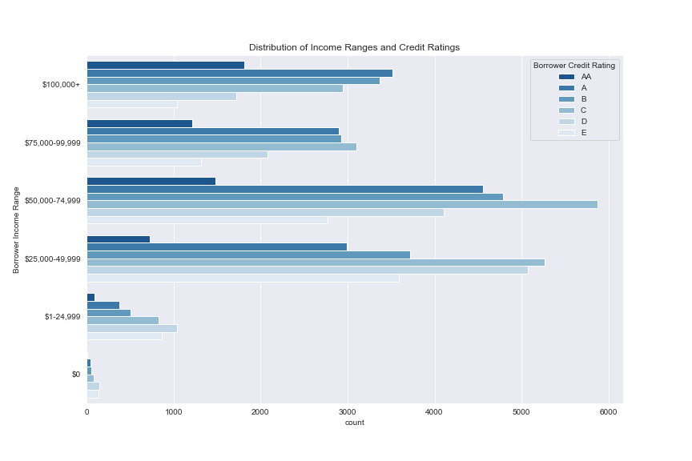

## Loan Amount per Employment Status

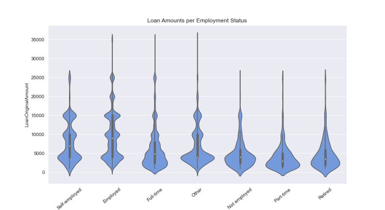

## Loan Term vs Credit Rating

> Unsuprisingly, across all loan term length there is a negaitve correlation between the amount given and credit rating. Borrowers with worse credit ratings are higher risk, and to give them a larger amount for a loan would not be worth the risk.

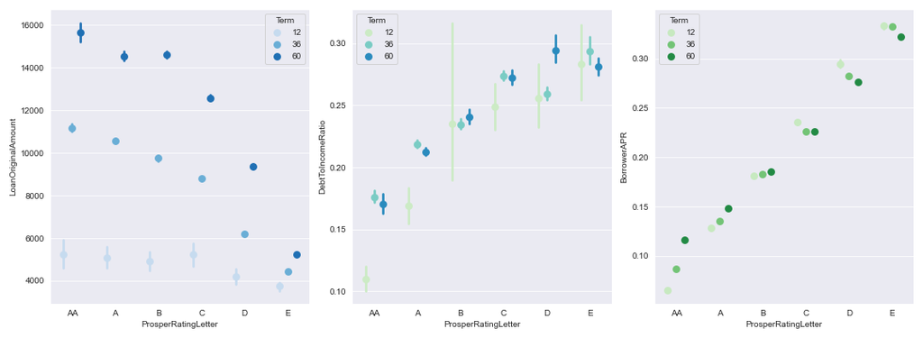

## Credit vs APR

> There is a clear negative correlation between credit rating and interest rate. The lower your credit score, the higher your interest rate. Meaning in the end you will pay more overall for your loan.

> It does appear that prosper may have a system where APR is fixed to credit rate, as the steps down by rate are almost uniform.

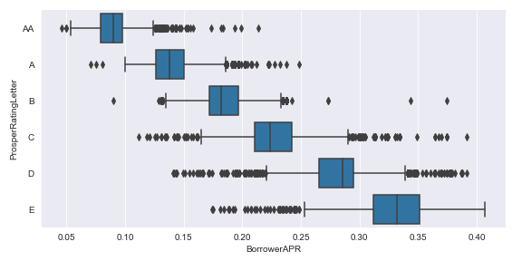

```python
!jupyter nbconvert Part_II_slide_deck_template.ipynb --to slides --post serve --no-input --no-prompt
```

```
^C
```